# Sociétés et environnements: des équilibres fragiles

Risques et tensions sur les ressources

Auteur·rice

Skarbimir Prokopek

## Introduction: sociétés et milieux

Durant l’été 2026, des feux de forêt records ont frappé la France. La canicule frappe très tôt dans l’année. La sécheresse reprend: depuis plusieurs années, les nappes phréatiques étaient à des niveaux très bas, les forêts étaient sèches. Les pluies de l’hiver avaient partiellement restauré les niveaux d’eau mais dès le début de l’été, on revient partout à la sécheresse pluriannuelle. Au mois de juin et de juillet, les incendies de forêt se multiplient. Leur ampleur bat les records; des massifs jusque là à l’abri, comme la forêt de Fontainebleau, sont frappés, d’autres, comme la forêt d’Ermenonville, au Nord de Paris, sont considérés à risque. La sidération des populations se reflète dans la couverture médiatique de ces catastrophes. La photo d’un couple de touristes contemplant les fumées depuis une plage de Gironde devient un symbole de ce moment apocalyptique.

[figure not shown]

Un couple de vacanciers sur la plage de Moutchic contemple Lacanau en flammes, photo virale de Maximilien Lamy, AFP, 24 juillet 2026

Si les incendies de 2026 dépassent ce que la France a connu les années précédentes, le phénomène n’est pas nouveau. Les forêts méditerranéennes ou encore celle des Landes brûlent tous les ans, le réchauffement climatique augmentant encore les rythmes saisonniers et les effets des aménagements humains.

[figure not shown]

Incendies en France, 2016-2025, carte de Jean-Marc Viglino, Atelier de cartographie thématique de l’IGN

Ces événements récents et traumatisants pour les habitants illustrent une relation compliquée entre les **sociétés** et leurs **environnements**

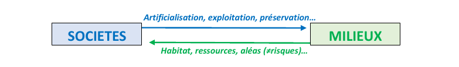

Schéma des relations entre sles sociétés et les milieux

Pour comprendre cette relation, il faut avoir en tête l’organisation générale des **foyers de peuplement** d’une part, et d’autre part celle des **milieux** de la planète. Cf. les cartes du **manuel (Hatier), pp. 12-13, 32-33 et 34-35**.  
Les **foyers de peuplement** se situent pour la plupart dans les zones **littorales**: l’Europe, l’Asie du Sud, Asie du Sud-Est et de l’Est, Nord-Est des États-Unis (ces trois foyers, Europe, Amérique du Nord littorale et Asie de l’Est correspondent à des centres bien établis de la mondialisation, parfois désignés encore comme les *sommets de la Triade*), le Sud-Est du Brésil, le Golfe de Guinée.

Les **milieux** s’organisent, à l’échelle mondiale, en bandes selon la **latitude** géographique: les milieux polaires, froids et secs avec une végétation peu abondante et adaptée aux contraintes (froid, faible luminosité); milieux tempérés, assez humides, marqués par des saisons très variables; milieux tropicaux chauds et humides; milieux arides (secs). Les milieux de montagne sont en général plus humides que l’espace environnant, la température baisse avec l’élévation et peut être très basse si l’altitude est suffisante, même dans les latitudes basses; les pentes introduisent des contraintes spécifiques et l’étagement de la végétation (partant d’un climat tempéré, l’on observe un étage de forêt de feuillus, puis celui des conifères, puis celui des alpages, en herbe, enfin un étage nival, fait de roches nues et de neiges)

**Comment les sociétés interagissent-elles avec leurs milieux de vie?**

### L’Arctique: Un espace entre fragilité et attractivité

Une étude de cas sur l’espace arctique est proposée dans le manuel, pp. 20-23.

L’espace arctique est situé autour du **pôle Nord de la Terre** (nous nous contentons ici du pôle géographique, c’est-à-dire le point où l’axe de rotation de la Terre traverse la surface terrestre; nous mettrons de côté la pôle magnétique). La définition conventionnelle de l’espace arctique est celle de l’espace compris dans le cercle polaire (approximativement 66°33` de latitude Nord), ou limite au-delà de laquelle il existe au moins une journée où le Soleil ne se lève pas en hiver et ne se couche pas en été.

Cette définition reste relativement abstraite. En pratique, on se réfère plus souvent à des caractéristiques du milieu: la **toundra** (végétation de mousses, lichens et petits arbustes) sur les terres émergées, la présence de l’**inlandsis** (glacier terrestre, à distinguer des glaces marines et des glaciers de montagne), au Groenland, ainsi que la **banquise** (glace marine). D’un point de vue politique, cet espace correspond aux territoires de 8 États: Russie, Norvège, Danemark (qui exerce la souveraineté sur le Groenland), Islande, Canada, États-Unis, Suède et Finlande. En raison de toutes les contraintes de vie dans un tel milieu, cet espace est très peu peuplé.

#### Un espace de plus en plus convoité

Cf. le croquis doc. 5, p. 21 dans le manuel.

L’Arctique est un espace de plus en plus attractif: la récente volonté du président américain Donald Trump d’acquérir (par l’achat, mais le président américain est allé jusqu’à menacer d’invasion militaire) le Groenland illustre l’importance que cet espace prend aux yeux des dirigeants actuels.  
Des **ressources** nombreuses y sont présentes: les **hydrocarbures** (pétrole et, surtout, gaz naturel) au Nord du Canada et de la Russie, ainsi que dans la Mer du Nord, mais aussi des ressources **minérales**: minerais de fer, d’or, de zinc et d’uranium. Ces ressources sont difficiles d’accès. Cependant, les avancées techniques dans le domaine minier permet d’envisager leur exploitation. La **raréfaction** de nombreuses parmi ces ressources (dont les réserves plus accessibles sont en voie d’épuisement) rendent cela économiquement plus intéressant. Enfin, le **réchauffement climatique** facilite également la tâche.

D’autre part, l’Arctique est un **espace stratégique** qu’il est important de contrôler. La **fonte des glaces** permet d’ouvrir des voies maritimes nouvelles: le **passage du Nord-Ouest**, qui consisterait à passer de l’Atlantique au Pacifique en passant entre les îles du Nord canadien et en longeant les côtes de l’Alaska, et surtout le **passage du Nord-Est**, voie maritime longeant les côtes Nord de la Russie. Les premières navigations commerciales sur ce second itinéraire ont déjà eu lieu, bien qu’elles soient encore peu nombreuses: la route reste dangereuse, les côtes du grand Nord russe sont désertes et peu aménagées, et les tensions internationales (notamment depuis l’invasion russe de l’Ukraine à partir de 2022 découragent de nombreux acteurs de l’emprunter). Cet itinéraire permettrait de raccourcir le trajet entre l’Europe et l’Asie, tout en donnant un rôle nouveau à la Russie.

D’un point de vue stratégique, l’espace arctique, longtemps impraticable, est devenu accessible à certains équipements (missiles, avions, sous-marins) dans les années d’après-guerre. Dès lors, l’Arctique est devenue un champ de bataille de la Guerre froide, abritant les bases maritimes soviétiques, mais aussi les activités maritimes américaines et des bases importantes en Alaska, Groenland et Islande. Les tensions actuelles autour de la délimitation des fonds marins prolongent cette compétition.

Dans les dernières années, au commerce maritime s’est ajouté le **tourisme**: l’activité des **croisières**, à destination d’une clientèle aisée, s’est rapidement développé. Par conséquent, l’espace arctique connaît une fréquentation bien plus importante que par le passé, ce qui augmente le risque de **pollution** (rejets des navires, potentielles catastrophes, mais aussi les ordures produites par les touristes, sans oublier le bruit).

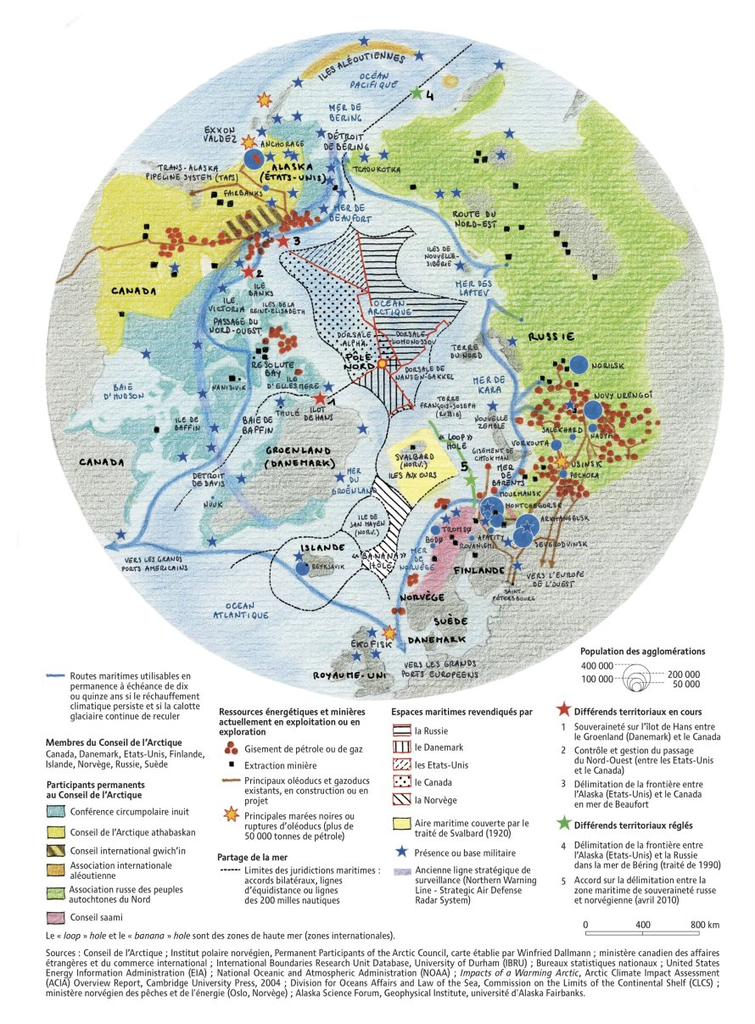

#### Un milieu fragilisé

L’espace arctique est un milieu fragile, très impacté par le **réchauffement climatique**, dû aux activités humaines. Les cartes illustrent abondamment le **recul de la banquise**. L’étendue de la glace marine varie durant l’année, elle s’agrandit durant l’hiver et recule en été. Cependant, les reculs ont été de plus en plus importants, alors que la reconstitution de la glace en hiver s’affaiblit rapidement.  
Des températures estivales inhabituellement élevées ainsi que des hivers particulièrement doux se généralisent: doc. 2 p. 20 mentionne des températures au Nord de la Norvège. Les équilibres biologiques sont perturbés: certaines espèces, dont les plus emblématiques, comme les ours polaires ou les phoques, dépendent de la banquise. Des oiseaux marins sont privés de nourriture lorsque les poissons qu’ils attrapaient se réfugient dans les profondeurs marines à la recherche de l’eau plus froide. Le réchauffement permet à des espèces venues des régions plus au Sud d’occuper de nouveaux territoires, en repoussant les espèces adaptées aux contraintes du froid qui perdent ainsi leur habitat.

Sur les terres émergées, la toundra recule, mettant en danger les populations de rennes et, indirectement, le mode de vie traditionnel des populations locales qui vivaient de leur élevage. Le **pergelisol**, ou *permafrost*, terre qui demeure en permanence gelée en profondeur (seule une mince couche superficielle dégèle en été, formant des marécages), se met désormais à fondre. Or, cette terre qui conserve des restes organiques très anciens retient ainsi des quantités énormes de carbone qui s’échappe dans l’atmosphère sous forme de gaz carbonique (CO<sub>2</sub>) et, pire, de méthane (CH<sub>4</sub>), lorsque la matière organique commence à nouveau à se décomposer. Cela risque d’accélerer considérablement le réchauffement climatique.

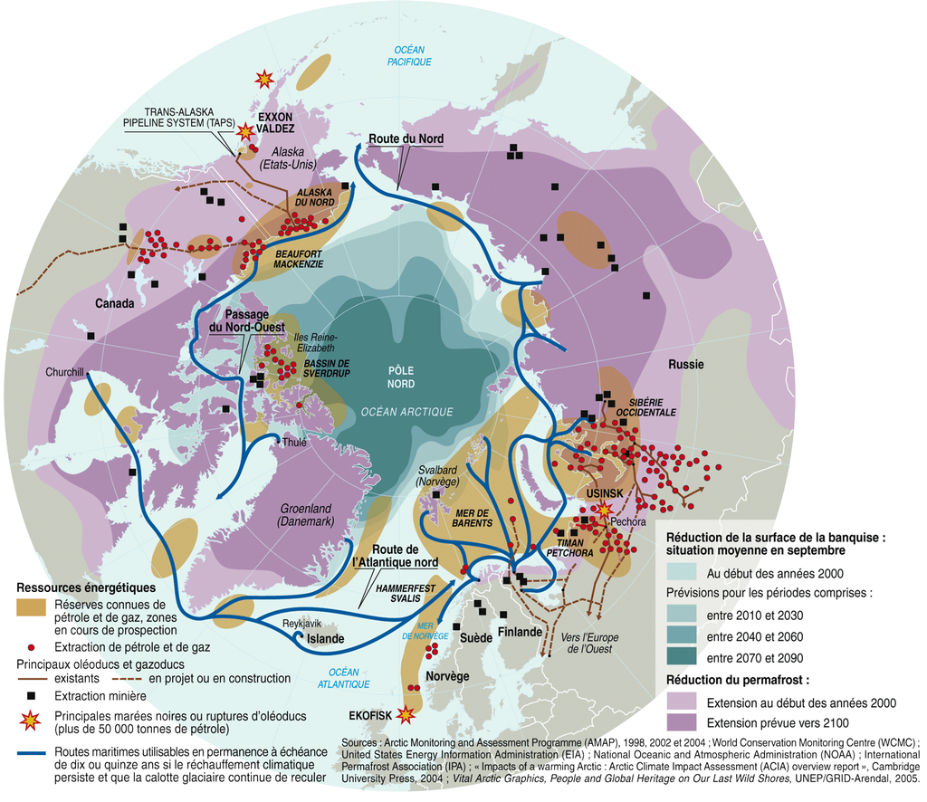

Réchauffement climatique dans la région arctique, par Frédéric Durand, *Le Monde diplomatique*, 2006

#### La protection du milieu arctique

Les initiatives pour protéger le milieu arctique sont confrontées aux difficultés de coordonner les différents acteurs, qui préfèrent souvent poursuivre leurs intérêts stratégiques et économiques.

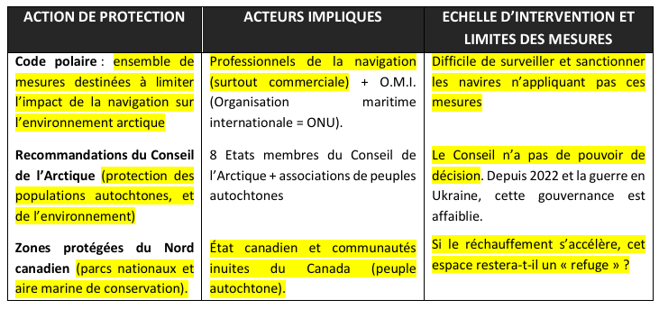

Tableau des actions de protection rempli en cours:

## 1 Les sociétés face aux risques

### 1.1 La diversité des risques

Le **risque** désigne la rencontre d’un **aléa** et d’une **vulnérabilité**. Autrement dit, c’est la possibilité qu’un **aléa** se produise et touche une population **vulnérable**.

L’**aléa** est un phénomène dangereux qui échappe à notre contrôle; il peut être naturel ou technologique. La **vulnérabilité** renvoie à un niveau d’effet prévisible de ce phénomène sur des **enjeux** (êtres humains ou leur activités). On parle de **catastrophe** lorsque le risque se réalise et entraîne de nombreuses victimes.

[figure not shown]

Schéma du risque comme association d’un aléa avec une vulnérabilité. Source: [*Géoconfluences*](https://geoconfluences.ens-lyon.fr/glossaire/risque-s)

En pratique: des phénomènes comme tremblements de terre, éruptions volcaniques ou avalanches ont toujours existé, mais ne constituent un risque que s’il y a des êtres humains ou activités susceptibles d’en souffrir. Un volcan qui entre en éruption sur une île inhabitée n’avait tout au plus que des conséquences indirectes sur la vie humaine, mais c’est un risque majeur lorsque la même île est habitée et densément peuplée. Les avalanches, que les montagnards connaissaient bien, ne mettaient que rarement en danger les éleveurs traditionnels qui ne s’y exposaient jamais, mais sont devenues un risque important lorsque les montagnes ont commencé à être fréquentées massivement en hiver par des skieurs.

Les risques **naturels** se rapportent à des aléas qui font intervenir des processus naturels variés; c’est en réalité l’aléa, et non le risque qui est «naturel», puisqu’il n’y a pas de risque sans la vulnérabilité humaine. Par ailleurs, la «naturalité» de l’aléa n’exclut pas une responsabilité humaine. LEs phénomènes météorologiques extrêmes (tornades, cyclones…) sont plus nombreux et plus puissants en raison du [**réchauffement climatique**](https://geoconfluences.ens-lyon.fr/informations-scientifiques/dossiers-thematiques/changement-global/articles-scientifiques/rechauffement-climatique-politiques-climatiques). À une échelle plus locale, les avalanches et les glissements de terrain sont également plus fréquents. Mais cette responsabilité est indirecte et non intentionnelle.

#### 1.1.1 L’inégale exposition aux risques

Les principaux risques de nature géologique (tremblements de terre, tsunamis, volcanisme) et climatique (cyclones, inondations) peuvent être situés à l’échelle mondiale. Les risques géologiques suivent les lignes des failles tectoniques et sont particulièrement nombreux dans la région de la **ceinture de feu** pacifique. Les littoraux et les vallées fluviales sont exposés aux phénomènes météorologiques extrêmes et aux inondations.

Or, dans ces régions, les aléas plus fréquents rencontrent aussi des enjeux et une vulnérabilité plus grande: c’est sur les littoraux et dans les vallées fluviales que les densités de populations sont plus grandes (par conséquent, l’aléa qui s’y produit a plus de chance de toucher des gens). Cela est particulièrement visible en Asie du Sud et de l’Est, partie du monde où se trouvent les plus grandes **mégapoles**.

#### 1.1.2 Les risques et les activités humaines

Les **risques technologiques** sont liés aux activités humaines, notamment la production de l’énergie (centrales nucléaires, barrages hydroélectriques…), l’extraction et transport (mines, forages pétroliers, marées noires), mais aussi production industrielle. Certains types de production entraînent des risques qui touchent les employés de l’usine, les agents intervenant en cas d’accident (pompiers…), mais aussi les habitants des quartiers voisins: ce fut le cas dans les catastrophes célèbres, comme à Seveso, en Italie, en 1972, à Bhopal en Inde (1984), ou, en France, à Toulouse (AZF en 2001) ou à Rouen (Lubrizol, 2019).

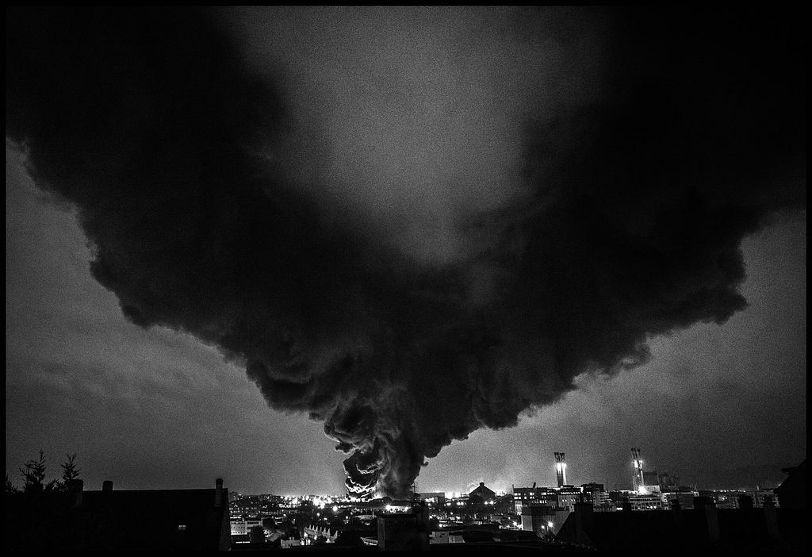

Incendie de l’usine Lubrizol à Rouen, 26 septembre 2019. Photo de Daniel Briot. L’usine, classée Seveso 2, synthétise et stocke des produits chimiques destinés à être des additifs des lubrifiants. Au cours de l’accident, il est révélé que la liste des produits dangereux présents sur le site était incomplète.

La hausse de la population mondiale et augmentation de la densité de population augmente la vulnérabilité, tant au risques naturels que technologiques. Le **changement climatique** (voyez la [synthèse de Magali Reghezza-Zitt à ce sujet](https://geoconfluences.ens-lyon.fr/informations-scientifiques/dossiers-thematiques/changement-global/articles-scientifiques/rechauffement-climatique-politiques-climatiques)) accroît la intensité et la fréquence des phénomènes climatiques, mais contribue aussi à rendre les sociétés plus vulnérables.

#### 1.1.3 Exemple du Japon

Le Japon, et plus particulièrement l’enchaînement des événements de 2011, fournit un excellent exemple[^1]. L’archipel japonais est exposé à pratiquement tous les aléas naturels imaginables: situé dans une zone très active géologiquement, le Japon subit régulièrement des tremblements de terre; automatiquement, le pays est aussi exposé aux **tsunamis** – ce n’est pas un hasard si le nom internationalement adopté de ce phénomène est emprunté à la langue japonaise. Ajoutons la présence des volcans, la fréquence des **typhons** ainsi que les précipitations qui peuvent être importantes et entraîner des risques typiques du milieu montagneux. Du point de vue de la vulnérabilité, la population (nombreuse) du Japon est concentrée sur les littoraux, ce qui aboutit à des densités parmi les plus élevées au monde.

<sup>1</sup> Je développe cet exemple à partir du [dossier de Rémi Scoccimaro, 2016](https://geoconfluences.ens-lyon.fr/informations-scientifiques/dossiers-regionaux/japon/corpus-documentaires/reconstruction-territoires-nord#section-0), sur le site *Géoconfluences*

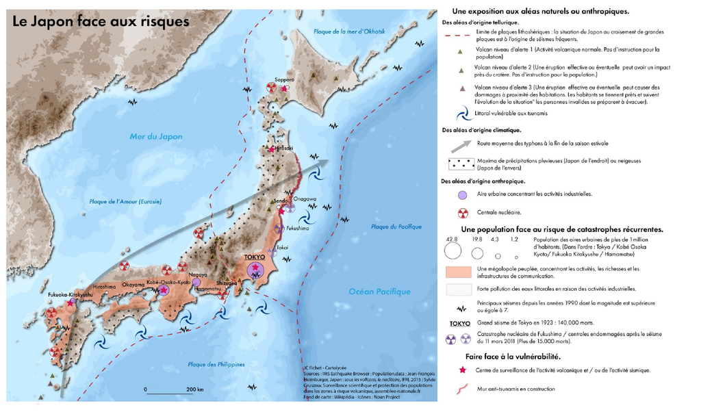

En contrepartie, les Japonais sont collectivement habitués à faire face à ces risques.

La catastrophe de 2011 est d’abord une catastrophe naturelle. C’est d’abord un tremblement de terre, de magnitude 9,1, ce qui en fait un des tremblements de terre les plus puissants jamais enregistrés. Les premiers dégâts sont liés directement à cet aléa (quelques effondrements d’immeubles, mais surtout des incendies causés par des canalisations rompues). Dans un premier temps, cependant, la préparation du pays est efficace: les destructions et les victimes sont peu nombreuses, bien moins que lors du tremblement de terre de Kobé en 1995. Mais sur le littoral, les sols sont fragilisés, si bien que les digues sont abaissées de 50 cm à 1.2 m.  
Entre 30 et 45 minutes après le séisme, les côtes du Nord-Est de Honshu sont frappées par le tsunami. Les vagues atteignent 40 mètres et provoquent l’inondation des zones basses côtières, jusqu’à 15 mètres. Selon la topographie, les zones inondées peuvent s’étendre sur quelques centaines de mètres comme dans les côtes basses, mais dans les vallées côtières typiques de la région du Sanriku, elles peuvent atteindre plus de dix kilomètres. Les vagues submergent les digues et surprennent des habitants qui s’étaient habitués à un sentiment de sécurité permis par ces ouvrages. Ainsi, le tsunami cause l’essentiel des victimes, dont 92% meurent noyées.

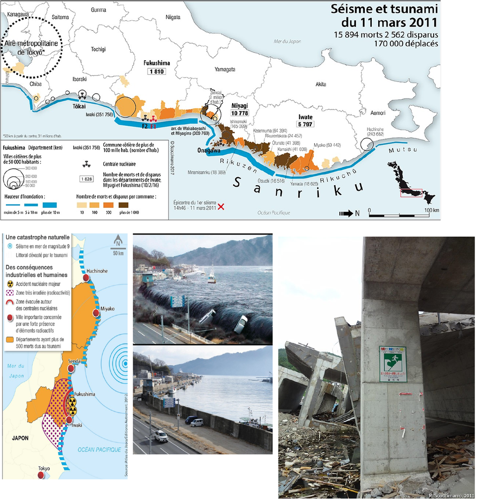

La destruction du Sanriku par le tsunami

Dans un troisième temps, la catastrophe naturelle **entraîne une catastrophe technologique**. La centrale nucléaire de Fukushima est exposée au tsunami; comme d’autres installations de ce type, elle est située sur le littoral pour pouvoir utiliser l’eau de mer pour le refroidissement.  
Lorsque le tremblement de terre est détecté, par mesure de sécurité, l’arrêt des réacteurs se déclenche. Or, l’énergie électrique est nécessaire pour cela: il faut alimenter les pompes de refroidissement alors même que l’on arrêt le réacteur. C’est pourquoi la centrale est équipée des générateurs diesel de secours. Mais le tsunami, de 13 m, dépasse les digues hautes de 10 m (pour une inondation prévue de 5.5 m) et noient ces diesels. Cela provoque la perte de contrôle des quatre parmi les six réacteurs du site. Au même moment, les centrales d’Onagawa, de Tokai et de Fukushima 2, plus récentes, résistent au tsunami. Les réacteurs 1, 2 et 3, les plus anciens, ne peuvent pas être arrêtés à froid. Entre le 12 et le 15 mars 2011, des explosions détruisent le réacteur 1 et relâchent un nuage radioactif qui se déplace dans le vent et dépose une pollution radioactive (Iode 131, dangereux pendant les premières heures mais responsable des cancers de la thyroïde, et surtout césium 137, dont la demi-vie d’environ 30 ans suffit pour contaminer certaines zones pour les trois prochains siècles).

### 1.2 L’inégale vulnérabilité des sociétés face aux risques

Nous passons de l’**aléa** à la **vulnérabilité**. Or, la vulnérabilité est très variable; si les aléas échappent en principe à l’action immédiate des sociétés, c’est sur la vulnérabilité (et, secondairement, sur la **résilience**) que s’exerce l’effort d’adaptation.

Un aléa peut frapper un pays développé comme un pays pauvre, mais le même aléa n’aura alors pas les mêmes effets humains ni matériels. Outre la question du peuplement (les dégâts seront logiquement plus importants là où il y a plus d’être humains, de bâtiments, d’équipements etc), la capacité des sociétés à faire face à l’aléa varient.  
**En 2023**, un tremblement de terre de magnitude 7.8 frappe la Turquie (pays classé comme émergent; son **IDH (Indice de développement humain)** est de 0.85). L’année suivante, un séisme similaire, de magnitude 7.6, se produit au Japon (IDH=0.92). L’impact est radicalement différent: en Turquie, 60 000 personnes perdent la vie, il n’y a que 281 morts au Japon. Les deux pays sont fortement peuplés, les densités au Japon sont même largement supérieures; mais les bâtiments construits rapidement à bas coût en Turquie ne résistent pas alors que les Japon impose depuis longtemps des normes de construction antisismique certes coûteuses, mais très efficaces. La **prévention** et la **préparation** jouent un rôle essentiel et sons en général plus efficaces dans les pays développés.  
Inversement, les **dommages économiques** tendent à être plus élevés dans les régions développées puisque les **infrastructures touchées** tendent à être plus coûteuses.

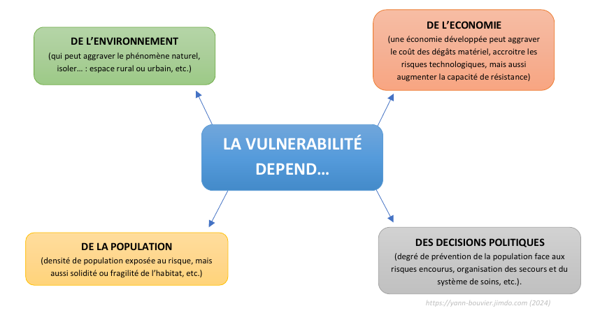

Pour reprendre l’exemple de la catastrophe de 2011: si le tsunami a été très meurtrier, ni le séisme initial, ni même la catastrophe nucléaire n’entraînent pas de victimes nombreuses. À la suite de l’explosion dans la centrale, une évacuation est menée de manière efficace. Cela crée des séquelles sociales (de nombreux habitants doivent être relogés…) et pose un problème du réaménagement des trrritoires touchés par la contamination, mais le réaction de la société japonaise à la cris s’avère efficace.

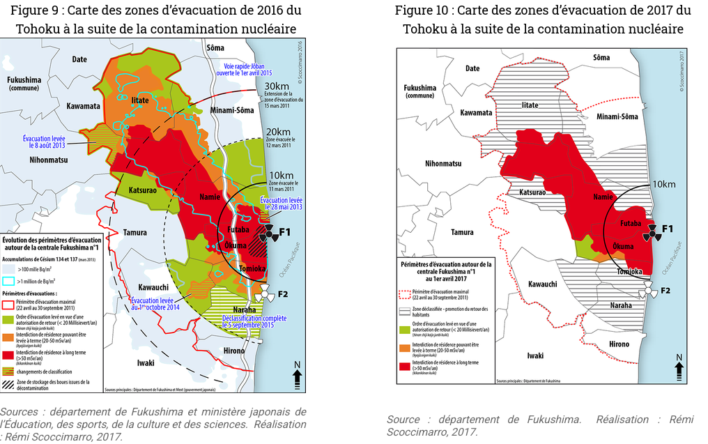

Cette catastrophe permet aussi d’évoquer la question de la **culture du risque**. La société japonaise est habituée à faire face à de nombreux risques naturels. Dans la région du Sanriku, connue pour être particulièrement exposée aux tsunamis, cette culture a été spécialement ancrée: après des catastrophes du passé, dont on a conservé le souvenir, des procédures d’urgence, des balisages des voies d’évacuation, des lieux refuges en hauteur etc ont été créés.  
Or, cette culture a été affaiblie par l’installation d’une population peu au fait de ce cappsé et habituée au sentiment de sécurité, à l’abri des digues et autres ouvrages d’art: ainsi une **culture de l’ingénieur** (où le risque devrait être maîtrisé par le déploiement des ouvrages de protection puissants, permis grâce aux avancements techniques) a supplanté la **culture du risque** qui repose sur la connaissance du risque et l’adaptation. R. Scoccimaro montre ue la catastrophe de 2011 n’a pas nécessairement changé cette tendance, des ouvrages imposants avant été construits depuis; ces derniers coupent parfois entièrement les villes côtières de la mer dont l’on se protège mais qu’on n’observe (et même, simplement, ne voit) plus.

## 2 Des ressources majeures sous pression: l’eau et l’énergie

L’exemple de l’eau: il s’agit d’une ressource limitée (une quantité plus ou moins fixe est présente sur terre) et indispensable à la vie. La **ressource en eau** renvoie exclusivement à l’eau douce et liquide, celle qui peut être consommée (à condition d’être assez propre). Ce n’est ni l’eau au sens chimique, ni (encore moins), le milieu aquatique comme espace de circulation: c’est un tout autre sujet.

L’eau dont on parle constitue à peine **0.7% de l’eau présente sur Terre**, dont la majorité est salée (97.5%); 1.8% d’eau terrestre est certes douce, mais est à l’état solide, prise dans les glaciers. Cela ne laisse que nos 0.7% aux eaux de surface (lacs, rivières) et les **nappes phréatiques**.

La quantité d’eau douce est pourtant largement suffisante, à l’échelle mondiale, pour les besoins de l’humanité – mais cette ressource est très inégalement repartie.

### 2.1 Une ressource inégalement disponible et inégalement accessible

Il faut distinguer la **disponibilité** en eau (rapport entre la quantité totale d’eau douce sur un territoire et le nombre d’habitants; par an) et l’**accessibilité** de l’eau pour les populations; cette dernière peut dépendre des l’état des infrastructures ou de la situation économique et politique. On peut manquer d’eau dans un pays qui en a beaucoup, comme on peut avoir toute l’eau dont on a besoin dans un pays très aride.

À l’échelle mondiale, les zones très arrosées s’étendent près des pôles et le long de l’Équateur. Les **précipitations** y sont importantes alors que les densités plutôt faibles.  
Les **milieux arides** caractérisent les zones autour des **Tropiques**, en particulier celui du Cancer. Ainsi les pays de l’Asie du Sud (qui combinent les densités importantes et les milieux semi-arides) connaissent le **stress hydrique**, tandis que l’Afrique du Nord ou le Proche Orient vivent en **pénurie d’eau**.

Du point de vue de l’**accessibilité** de l’eau, il faut considérer la qualité de la ressource. Le manque d’eau signifie concrètement moins l’absence d’eau (comme le suggèrent les illustrations faciles de l’idée du manque d’eau: la terre craquelée, les lits des rivières à sec…), c’est bien plus souvent la situation où l’eau accessible est sale. L’accès à l’**eau potable** est très inégal et tend à s’aligner sur la situation politique et économique: l’eau est en général facilement accessible dans les pays développés et émergents qui ont les moyens de construire et entretenir les infrastructures d’adduction et de traitement d’eau. L’exemple extrême serait l’Arabie Saoudite ou Israël, pays arides qui recourent massivement à des usines de dessalement d’eau de mer.  
Inversement, la **République démocratique du Congo (RDC)** a d’importantes réserves d’eau douce mais l’accessibilité de cette eau pour les populations y est difficile.

Dans le monde, 1 humain sur 4 n’a pas accès à l’eau potable, très majoritairement en Afrique subsaharienne.

### 2.2 Une ressource sous pression

Dans le monde, la consommation d’eau s’accroît fortement. Cela s’explique par **l’essor démographique** (entre 2024 et 2050, la population du monde devrait augmenter, selon les pronostics, de 20%, surtout en Afrique) d’une part et, d’autre part, par le développement économique. La hausse du niveau de vie, l’amélioration de la qualité de vie suppose un mode de vie plus consommateur; ce confort suplémentaire fait aussi appel à des produits industriels dont la production est consommatrice d’eau.

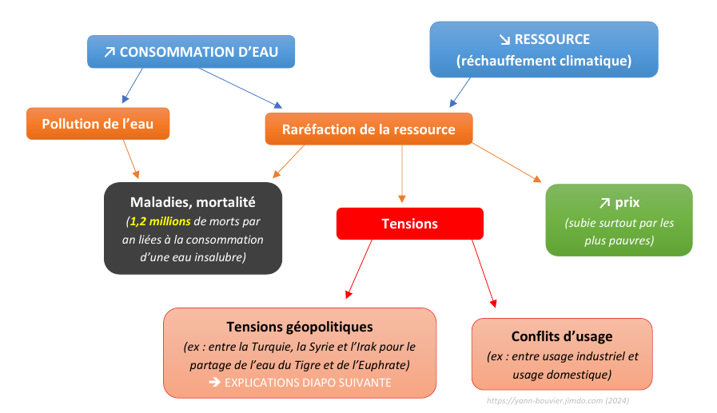

L’**exemple de l’Espagne**: le pays illustre l’inégalité de la distribution de la ressource en eau, le Nord bien arrosé de l’Espagne se distingue bien de la majorité du pays, plutôt aride. De manière frappante, la consommation d’eau est la plus importante là où la ressource est la moins abondante: la pression sur la ressource vient majoritairement des grandes villes, du littoral touristique ainsi que de l’agriculture intensive, très développée en Andalousie. Les serres andalouses, qui produisent la majorité des légumes consommés en Europe, fonctionnent ainsi largement en puisant l’eau dans une **nappe fossile**, qui n’est pas alimentée par les pluies et qui fonctionne localement comme une ressource non renouvelable.

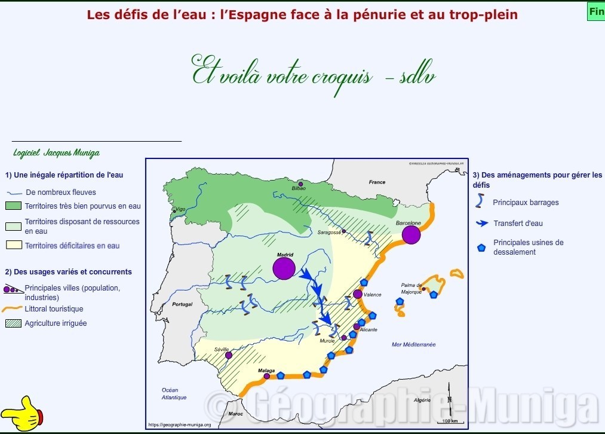

Corrigé de l’exercice de croquis sur l’Espagne, proposé par Jacques Muniga

## 3 Gérer durablement les risques et les ressources: vers une transition?

### 3.1 Mieux gérer les risques

Les **politiques de gestion des risques** nécessitent des moyens considérables et une **volonté politique** réelle. Il s’agit de systèmes de surveillance et d’alerte qui peuvent détecter le danger le plus tôt possible (ce qui suppose de mobiliser les avancées scientifiques dans la compréhension du climat, de la météorologie, du volcanisme etc) et d’avertir les populations; d’imposer des normes de construction, former des populations aux procédures d’urgence, enfin de disposer de systèmes de secours et de soins performants.

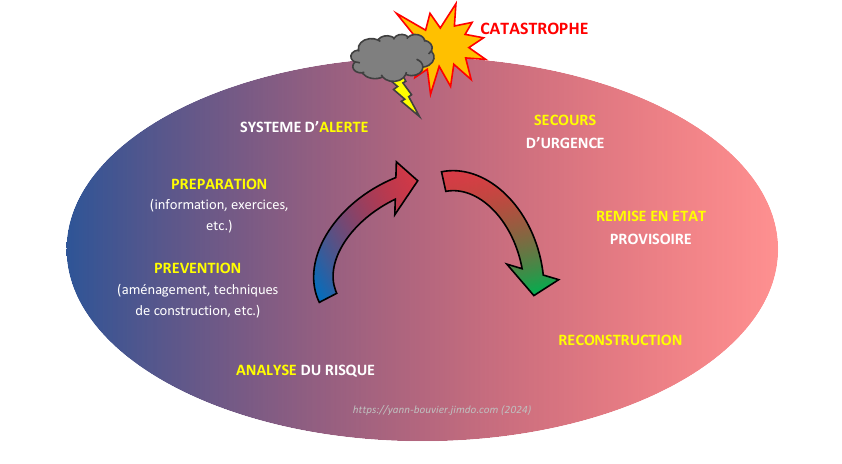

Schéma de la gestion des risques. Source: Yann Bouvier

Le Japon peut encore être donné en exemple: ce pays très développé est en mesure de mobiliser des services d’urgence très performants; sa population est non seulement protégée par des moyens matériels de pointe (construction antisismique qui fait régulièrement ses preuves, ouvrages de protection côtiers déjà cités…), mais elle est aussi formée aux procédures d’ urgence. Les programmes scolaires consacrent une large place aux divers risques qui touchent le pays, des exercices réguliers sont conduits pour réagir en cas de catastrophe.  
Tout cela n’est souvent pas possible pour un pays en développement. Ainsi le **Bangladesh** (cf étude de cas dans le manuel; certain.e.s l’ont peut-être étudié au collège) partage certaines caractéristiques avec le Japon: sa population est très nombreuse, les densités très élevés et les risques nombreux. Le pays est situé dans le delta du Gange, situé très bas en altitude (ce qui est l’inverse du Japon, très montagneux) et exposé aux inondations ainsi qu’à l’ élévation du niveau de la mer. Mais le Bangladesh fait partie des pays pauvres, ce qui limite les capacités des l’État bangladais à faire face et à protéger ses populations.

Toutefois, **disposer des moyens ne garantit pas encore de bien les employer**: la politique de prévention et gestion des risques nécessite des moyens mais doit aussi être pertinente et reposer sur une vraie volonté de protéger les populations. Or, cet objectif peut entrer en conflit (surtout à court terme) avec d’autres intérêts. L’entretien avec la géographe **Magali Reghezza-Zitt** et le climatologue Christophe Cassou, ci-dessous vous fournit une analayse des **inondations** qui ont eu lieu il y a quelques années en Espagne et dans le Sud de la France, mais parle aussi de ces difficultés politiques ainsi que du rôle que la connaissance des phénomènes peut avoir dans la gestion des risques:

[video not shown]

### 3.2 Mieux gérer les ressources: vers le développement durable?

Il est aujourd’hui évident que la tendance actuelle dans laquelle **le développement économique repose sur une augmentation de la consommation des ressources** (tous types de ressources: l’énergie, et l’eau certes, mais aussi de nombreuses ressources minérales, comme plusieurs métaux en voie d’épuisement) ne peut pas être maintenue indéfiniment. Face à la conscience que les ressources sont limitées et qu’il est indispensable de préserver la possibilité d’en bénéficier dans l’avenir, le modèle qui s’impose est le **développement durable**.  
Ce dernier peut être défini comme la manière de satisfaire les besoins actuels tout en préservant ceux des générations futures. C’est une application du **principe de précaution**.  
Plus pragmatiquement, le développement durable se présente comme un effort pour équilibrer les impératifs de **développement économique**, de manière à préserver un niveau de vie et surtout, d’améliorer celui des pays en développement; les nécessités de **protection de l’environnement** et de **justice sociale**.

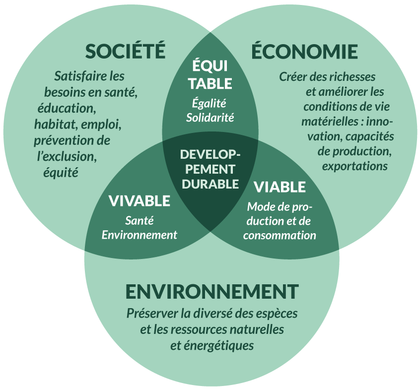

Diagramme du développement durable

Ce principe est **constitutionnalisé** en France, puisqu’il est inscrit dans la **Charte de l’environnement** de 2004, annexée à la Constitution en vigueur.

Cependant, le développement durable est critiqué. D’une part, l’équilibre entre les trois piliers (économique, environnemental et social) est difficile voire impossible à atteindre; les différents acteurs ont donc des priorités divergentes. Pour les pays émergents et en développement, les impératifs économiques de développement apparaissent les plus urgents, tandis que l’insistance des pays riches sur la protection de l’environnement est vue comme une manière de justifier que les pauvres acceptent de rester pauvres.

Au sein des pays développés, la volonté politique manque dès lors qu’il s’agit de mesures concrètes qui pourraient entrer en contradiction avec les intérêts économiques. Ainsi, les États-Unis de Donald Trump se sont deux fois retirés des accords de Paris de 2015 (en 2020 et 2026), le président américain étant un partisan de la recherche de développement économique sans entraves (cf son slogan *Drill, baby, drill*, endossant l’exploitation de nouvelles réserves de pétrole).

Enfin, du point de vie écologique, le modèle du développement durable est critiqué pour sa contradiction: l’idée de développement, donc d’augmentation constante de la production, n’est pas remise en cause, or cela ne peut avoir lieu sans une consommation accrue des ressources et aggravation du réchauffement climatique.

### 3.3 La transition écologique

Tandis que les spécialistes emploient rarement le terme de développement durable, l’objectif d’une *transition énergétique* s’impose comme une nécessité pour limiter les effets du réchauffement climatique (qui est déjà irréversible; selon la partie de l’environnement que l’on observe, il faudrait de quelques décennies à plusieurs millénaires pour que le climat retrouve son état «naturel» même si les émissions humaines des gaz à effet de serre disparaissaient du jour au lendemain complètement, ce qui est bien entendu impossible; la prochaine glaciation est déjà annulée, nous parlons donc d’une oscillation du climat à l’échelle des 10 000 ans).  
La transition correspond à l’objectif de limiter l’usage de l’énergie carbonée et des ressources fossiles pour favoriser un usage plus rationnel et efficient (grâce à des progrès) et à l’usage des ressources renouvelables. Il s’agirait de **décarboner** l’économie et d’atteindre le **découplage**, une situation hypothétique où la croissance de la production pourrait s’accompagner d’une baisse nette de la consommation de l’énergie et des émissions polluantes.

Or, de nombreux spécialistes mettent en doute la possibilité de ces objectifs et pointent que les transition énergétiques du passé (du bois au charbon, puis du charbon au pétrole) ont toujours été **cumulatives**, elles ont consisté à **ajouter** une nouvelle ressource dominante à l’ancienne dont l’usage continuait à augmenter. Par conséquent, c’est une **réduction nette de la consommation d’énergie** qui s’imposerait. Ce ralentissement volontaire et raisonné de l’économie serait la **décroissance** plutôt qu’un «développement durable». Cela suppose, à son tour, de changer en profondeur la manière de considérer l’économie et de remplacer les indicateurs actuels (tels que le PIB et ses dérivés) par des mesures plus adaptées à une économie gouvernée par les besoins et cherchant à préserver les ressources plutôt qu’à croître. Cette approche est encore peu acceptée dans le monde politique.